# Setup: Introduction Module

Stephanie Spielman for the Data Lab

2022-11-15

## Setup

### Download Data

This data comes from this 10x Genomics Dataset: https://software.10xgenomics.com/single-cell-gene-expression/datasets/6.0.0/10k_PBMCs_TotalSeq_B_3p.

To get the raw data:

```r
NAME=10k_PBMCs_TotalSeq_B_3p_raw_feature_bc_matrix.tar.gz
wget https://cf.10xgenomics.com/samples/cell-exp/6.0.0/10k_PBMCs_TotalSeq_B_3p/$NAME
tar -xf $NAME
# This gets unpacked into `raw_feature_bc_matrix`


# For posterity, first attempt was with MALT, but it had wildly low ADT counts
# Dataset link: https://www.10xgenomics.com/resources/datasets/10-k-cells-from-a-malt-tumor-gene-expression-and-cell-surface-protein-3-standard-3-0-0
#NAME=malt_10k_protein_v3_raw_feature_bc_matrix.tar.gz
#wget https://cf.10xgenomics.com/samples/cell-exp/3.0.0/malt_10k_protein_v3/$NAME
```

## Loading Data

```r
pbmc_10x_dir <- "raw_feature_bc_matrix"
# for now..
mito_file <- "https://raw.githubusercontent.com/AlexsLemonade/scpca-downstream-analyses/main/reference-files/Homo_sapiens.GRCh38.104.mitogenes.txt"


pbmc_sce_raw <- DropletUtils::read10xCounts(pbmc_10x_dir)
mito_genes <- readr::read_tsv(mito_file,
                              col_names="gene") %>%
  # only keep relevant mitochondrial genes
  dplyr::filter(gene %in% rownames(pbmc_sce_raw)) %>%
  dplyr::pull(gene)
# let's have a quick look at the raw SCE and genes:
pbmc_sce_raw
```

```
class: SingleCellExperiment
dim: 36611 2421702
metadata(1): Samples
assays(1): counts
rownames(36611): ENSG00000243485 ENSG00000237613 ... CD45 IgG1
rowData names(3): ID Symbol Type
colnames: NULL
colData names(2): Sample Barcode
reducedDimNames(0):
mainExpName: NULL
altExpNames(0):
```

```r
mito_genes
```

```
 [1] "ENSG00000198888" "ENSG00000198763" "ENSG00000198804" "ENSG00000198712" "ENSG00000228253" "ENSG00000198899"
 [7] "ENSG00000198938" "ENSG00000198840" "ENSG00000212907" "ENSG00000198886" "ENSG00000198786" "ENSG00000198727"
[13] "ENSG00000198695"
```

### Split antibody tag data

Before proceeding with further filtering, we’ll want to re-arrange the SCE object to handle the RNA and ADT separately. Currently, the ADTs and genes are both part of the primary experiment, so let’s move the ADT counts into an `altExp` slot.

```r
# We can see this in the `Type` column in the rowData() where the creators of this dataset
#  stored experiment information
unique(rowData(pbmc_sce_raw)$Type)
```

```
[1] "Gene Expression"  "Antibody Capture"
```

```r
# Split out the ADT into an altExp
pbmc_sce_split <- splitAltExps(pbmc_sce_raw,
                               #"Gene Expression" or "Antibody Capture"
                               rowData(pbmc_sce_raw)$Type,
                               # The Type which should be the main experiment
                               "Gene Expression")


# The names for the experiments were directly derived from `Type`:
mainExpName(pbmc_sce_split)
```

```
[1] "Gene Expression"
```

```r
altExpNames(pbmc_sce_split)
```

```
[1] "Antibody Capture"
```

```r
# But here on the computer, we don't like spaces, so let's rename it to something informative
#  and space-free, like "CITEseq" or "ADT". We'll use "ADT" since typing less > typing more
altExpNames(pbmc_sce_split) <- "ADT"

# And confirm:
altExpNames(pbmc_sce_split)
```

```
[1] "ADT"
```

```r
# We can do this for main if we want too!
#mainExpName(pbmc_sce_split) <- "RNA"
```

### Quick ADT exploration

Let’s look at our ADTs:

```r
# Here's how we can see the altExp itself - it's its own SCE object
altExp(pbmc_sce_split)
```

```
class: SingleCellExperiment
dim: 10 2421702
metadata(1): Samples
assays(1): counts
rownames(10): CD3 CD4 ... CD45 IgG1
rowData names(3): ID Symbol Type
colnames: NULL
colData names(0):
reducedDimNames(0):
mainExpName: NULL
altExpNames(0):
```

```r
# What are the tags?
rownames(altExp(pbmc_sce_split))
```

```
 [1] "CD3"   "CD4"   "CD8"   "CD11c" "CD14"  "CD16"  "CD19"  "CD56"  "CD45"  "IgG1"
```

These are all human surface proteins except `IgG1`, which is a mouse isotype that was used as a control, which we can determine via the Excel sheet “Download the excel file for a full list of clones and barcodes” from the kit page: https://www.biolegend.com/en-us/products/totalseq-b-human-universal-cocktail-v1dot0-20960?GroupID=GROUP28

If there’s no contamination, we expect ~0 counts for this protein since the data is human:

```r
# Here's the counts assay:
counts(altExp(pbmc_sce_split))
```

```
10 x 2421702 sparse Matrix of class "dgCMatrix"

CD3   . . . . . . . . . . . . . . . . . . . . . . . 1 . . . . .  62 . . . . . . . . . . . . . . . . . 1 . .
CD4   . . . . . . . . . 1 . . . . . . . . . 1 . . . . . . . . .  83 . . . . . . . . . . . . . . . . 1 . . .
CD8   . . . . . . . . . . . . . . . . . . . . . . . . . . . . .   8 . . . . . . . . . . . . . . . . . . . .
CD11c . . . . . . . . . . . . . . . . . . . . . . . . . . . . .  32 . . . . . . . . . . . . . . . . . . . .
CD14  . . . . . . . . . . . . . . . . . . . . . 2 . . 1 . . 1 . 109 . . . . . . . . . . . . . . . . . . . .
CD16  . . . . . . . . . . . . . . . . . . . . . . . . . . . . .  29 . . . . . 1 . . . 1 . . . . . . . . . .
CD19  . . . . . . . . . . . . . . . . . . . . . . . . . . . . .  55 . . . . . . . . . . . . . . . . . . . .
CD56  . . . . . . . . . . . . . . . . . . . . . . . . . . . . .  63 . 1 . . . 1 . 1 . . 1 . . . . . . . . .
CD45  . . . . . . . . . . . . . . . . . . . . . . . . . . . . .   3 . . . . . . . . . . . . . . . . . . . .
IgG1  . . . . . . . . . . . . . . . . . . . . . . . . . . . . .   . . . . . . . . . . . . . . . . . . . . .

CD3   ......
CD4   ......
CD8   ......
CD11c ......
CD14  ......
CD16  ......
CD19  ......
CD56  ......
CD45  ......
IgG1  ......

 .....suppressing 2421652 columns in show(); maybe adjust 'options(max.print= *, width = *)'
 ..............................
```

```r
# Use rowSums to see totals:
# Wow, almost no IgG1! Hurray.
rowSums(counts(altExp(pbmc_sce_split)))
```

```
     CD3      CD4      CD8    CD11c     CD14     CD16     CD19     CD56     CD45     IgG1
 5264144  8693064  1227181  5768360 15271714  3853459  6140220  6515196  1122268     1520
```

> At this point we could consider removing cells with IgG1 > 0 and remove the antibody entirely.

### Filter RNA

#### First, with `DropletUtils`

```r
# Filter RNA
droplet_df <- DropletUtils::emptyDropsCellRanger(
  counts(pbmc_sce_split),
  BPPARAM = BiocParallel::MulticoreParam(4)
)

# Filter down to low FDR cells and check out dimensions
# Values here are mostly NA.
# NOTE: this filtering does propagate to altExp!! :)
cells_to_retain <- which(droplet_df$FDR <= 0.01)
filtered_sce <- pbmc_sce_split[, cells_to_retain]
dim(pbmc_sce_split)  # before filtering
```

```
[1]   36601 2421702
```

```r
dim(filtered_sce)  # after filtering
```

```
[1] 36601  9248
```

#### Now, with `miQC`

We’ll need some mitochondria stats for `miQC`:

```r
filtered_sce <- scater::addPerCellQC(
  filtered_sce,
  subsets = list(mito = mito_genes))


# See that `sum` is RNA only and `total` is both RNA and ADT
head(filtered_sce$sum)
```

```
[1]  6238 13382  7198  6024  5023 13076
```

```r
head(filtered_sce$total)
```

```
[1]  7214 14970  9484  7535  5770 16491
```

```r
all(filtered_sce$total >= filtered_sce$sum) # total is never going to be LOWER than sum
```

```
[1] TRUE
```

First we’ll build the `miQC` model and visualize it, including how it suggests to filter the cells.

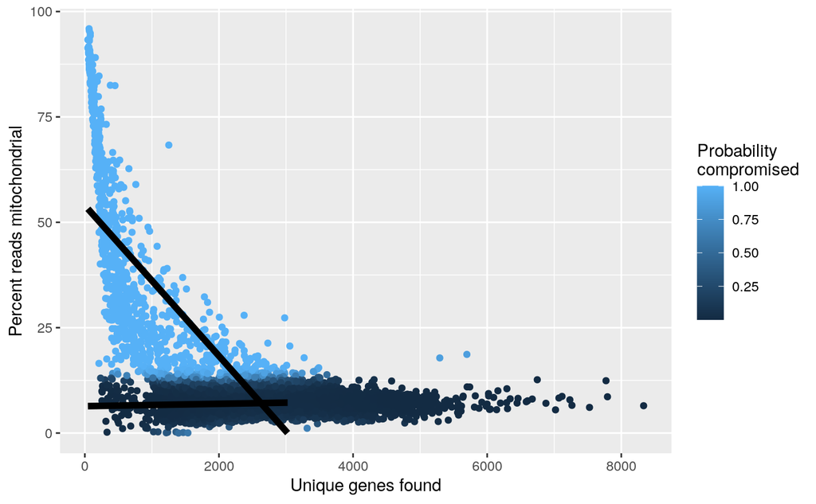

```r
miqc_model <- miQC::mixtureModel(filtered_sce)

# Show some miQC plots -
miQC::plotModel(filtered_sce, miqc_model)
```

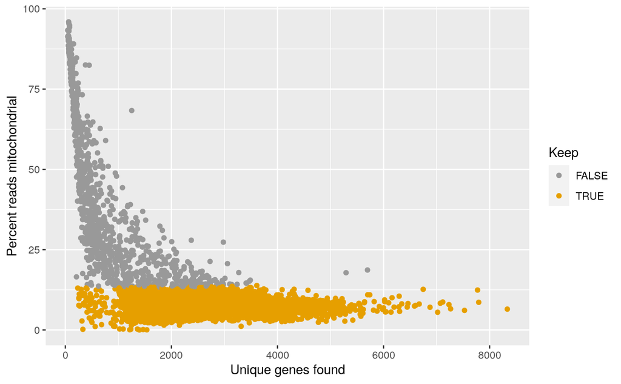

```r
miQC::plotFiltering(filtered_sce,
                    miqc_model)
```

Now, let’s filter based on `miQC`:

```r
# Apply miQC filtering
filtered_sce <- miQC::filterCells(filtered_sce,
                                  model = miqc_model)
```

```
Removing 983 out of 9248 cells.
```

```r
# What's left?
dim(filtered_sce)
```

```
[1] 36601  8265
```